# project2a-Copy1

```python
import zipfile
import pandas as pd

# Define the file path and extract the contents of the uploaded zip file
file_path = 'C:/Users/lOKITHA/Downloads/archive.zip'
extracted_path = 'Churn_data.csv'

# Extract the zip file
with zipfile.ZipFile(file_path, 'r') as zip_ref:
    zip_ref.extractall(extracted_path)

# List the extracted files to see what we have
import os
extracted_files = os.listdir(extracted_path)
extracted_files
```

```
['churn_data.csv',
 'customer_data.csv',
 'internet_data.csv',
 'Telecom Churn Data Dictionary.csv']
```

This code performs a series of steps to load, clean, and analyze the dataset. Here's a breakdown of what each part of the code does:

### 1. **Extracting the ZIP File**:

- **Zip Extraction**: The code extracts a ZIP file (`archive.zip`) located at `C:/Users/lOKITHA/Downloads/` and extracts its contents into a folder named `Churn_data.csv`.
- **Extracted Files Listing**: After extracting, the list of files in the extracted folder is stored in `extracted_files`.
- **Reading the CSV**: The file `churn_data.csv` is read into a pandas DataFrame (`churn_data`), which contains the customer churn data.

### 2. **Exploring the Dataset**:

- **Basic Info**: The `info()` function is used to get a summary of the DataFrame, including the number of non-null entries, data types, and memory usage.
- **First Few Rows**: `head()` is used to preview the first few rows of the dataset, helping you understand its structure (columns and data).

### 3. **Cleaning the 'TotalCharges' Column**:

- The `TotalCharges` column is converted to numeric, using `pd.to_numeric()`. The `errors='coerce'` argument ensures that any non-numeric values are converted to `NaN`.

### 4. **Checking for Missing Values**:

- **Missing Values**: The code checks for missing values in the dataset using `isnull().sum()`, which returns the number of missing values per column.
- **Handling Missing Data**: After identifying missing values, rows with missing values are dropped using `dropna()`, resulting in `churn_data_cleaned`.

### 5. **Analyzing the 'Churn' Distribution**:

- **Churn Distribution**: The `value_counts(normalize=True) * 100` method calculates the percentage distribution of churn (i.e., how many customers churned vs. did not churn). This helps to check the balance between the churn and non-churn classes.

### 6. **Summary of Cleaned Dataset**:

- **Cleaned Data Info**: After handling missing values, the cleaned dataset's summary is displayed using `info()` to confirm the shape and data types of the cleaned data.

### Outputs:

1. **Missing Values**: The count of missing values per column before cleaning.
2. **Churn Distribution**: The percentage of customers who churned vs. those who did not.
3. **Cleaned Data Info**: A summary of the dataset after cleaning, including non-null counts and data types.

### Purpose:

- **Data Exploration**: Understand the structure of the dataset and identify any issues, like missing or erroneous values.
- **Data Cleaning**: Handle missing values and convert data to appropriate types for further analysis.
- **Churn Analysis**: Check how imbalanced the churn distribution is and prepare for model building or deeper analysis.

Let me know if you need further clarification or help with this code!

```python
import zipfile
import pandas as pd
import os

# Define the file path and extract the contents of the uploaded zip file
file_path = 'C:/Users/lOKITHA/Downloads/archive.zip'
extracted_path = 'Churn_data.csv'

# Extract the zip file
with zipfile.ZipFile(file_path, 'r') as zip_ref:
    zip_ref.extractall(extracted_path)

# List the extracted files to see what we hav
extracted_files = os.listdir(extracted_path)
extracted_files
churn_data_path = os.path.join(extracted_path, 'churn_data.csv')
churn_data = pd.read_csv(churn_data_path)

# Display basic information and the first few rows of the dataset to understand its structure
churn_data_info = churn_data.info()
churn_data_head = churn_data.head()

churn_data_info, churn_data_head


# Step 1: Clean the 'TotalCharges' column by converting to numeric and handling errors
churn_data['TotalCharges'] = pd.to_numeric(churn_data['TotalCharges'], errors='coerce')

# Step 2: Check for missing values in the dataset
missing_values = churn_data.isnull().sum()
print("MISSING VALUES",missing_values)

# Step 3: Drop rows with missing values (if any) or handle them
churn_data_cleaned = churn_data.dropna()

# Step 4: Analyze the distribution of the 'Churn' column
churn_distribution = churn_data_cleaned['Churn'].value_counts(normalize=True) * 100

# Step 5: Summary of the cleaned dataset
cleaned_info = churn_data_cleaned.info()

missing_values, churn_distribution, cleaned_info
```

```
<class 'pandas.core.frame.DataFrame'>
RangeIndex: 7043 entries, 0 to 7042
Data columns (total 9 columns):
 #   Column            Non-Null Count  Dtype
---  ------            --------------  -----
 0   customerID        7043 non-null   object
 1   tenure            7043 non-null   int64
 2   PhoneService      7043 non-null   object
 3   Contract          7043 non-null   object
 4   PaperlessBilling  7043 non-null   object
 5   PaymentMethod     7043 non-null   object
 6   MonthlyCharges    7043 non-null   float64
 7   TotalCharges      7043 non-null   object
 8   Churn             7043 non-null   object
dtypes: float64(1), int64(1), object(7)
memory usage: 495.3+ KB
MISSING VALUES customerID           0
tenure               0
PhoneService         0
Contract             0
PaperlessBilling     0
PaymentMethod        0
MonthlyCharges       0
TotalCharges        11
Churn                0
dtype: int64
<class 'pandas.core.frame.DataFrame'>
Index: 7032 entries, 0 to 7042
Data columns (total 9 columns):
 #   Column            Non-Null Count  Dtype
---  ------            --------------  -----
 0   customerID        7032 non-null   object
 1   tenure            7032 non-null   int64
 2   PhoneService      7032 non-null   object
 3   Contract          7032 non-null   object
 4   PaperlessBilling  7032 non-null   object
 5   PaymentMethod     7032 non-null   object
 6   MonthlyCharges    7032 non-null   float64
 7   TotalCharges      7032 non-null   float64
 8   Churn             7032 non-null   object
dtypes: float64(2), int64(1), object(6)
memory usage: 549.4+ KB
```

```
(customerID           0
 tenure               0
 PhoneService         0
 Contract             0
 PaperlessBilling     0
 PaymentMethod        0
 MonthlyCharges       0
 TotalCharges        11
 Churn                0
 dtype: int64,
 Churn
 No     73.421502
 Yes    26.578498
 Name: proportion, dtype: float64,
 None)
```

This code visualizes and analyzes churn data using various plots to understand patterns based on different features. Here's a breakdown of each step:

### 2. **Analyze Churn Based on Contract Type**:

- **Plot Type**: `countplot` with hue based on the `Churn` column.
- **Description**: This plot visualizes churn distribution across different contract types (e.g., month-to-month, one-year, two-year). The `hue='Churn'` argument separates the counts by churn status.
- **Purpose**: Reveals if customers with certain contract types are more likely to churn, helping identify which contract types may correlate with higher churn rates.

### 3. **Analyze Churn Based on Tenure (Categorized)**:

- **Plot Type**: `countplot` with the `TenureGroup` column (which is created by binning the `tenure` column into 6 groups based on months).
- **Description**: The `TenureGroup` divides the customers' tenure into different ranges (e.g., 0-12 months, 13-24 months, etc.), and churn is visualized for each group.
- **Purpose**: Helps to identify if there’s a relationship between a customer’s tenure (how long they've been with the company) and their likelihood to churn.

### 4. **Analyze Churn Based on Payment Method**:

- **Plot Type**: `countplot` with the `PaymentMethod` column on the y-axis.
- **Description**: This plot shows the churn distribution based on different payment methods (e.g., electronic check, mailed check, etc.), with churn separated by color.
- **Purpose**: Identifies if certain payment methods correlate with higher churn rates, which may indicate customer preferences or dissatisfaction.

### General Purpose:

The plots provide insights into how different customer features (e.g., contract type, tenure, payment method) relate to churn behavior, which can guide further analysis or model feature selection. These visualizations are useful for identifying key factors influencing churn.

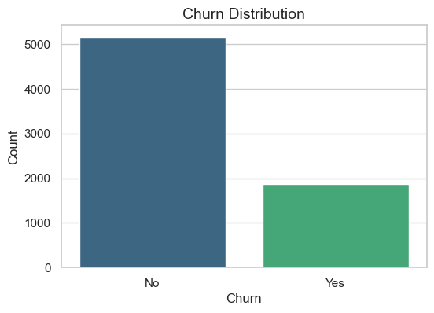

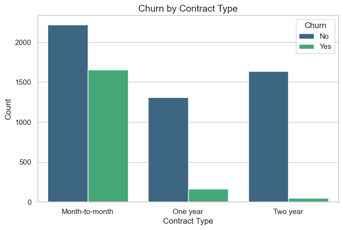

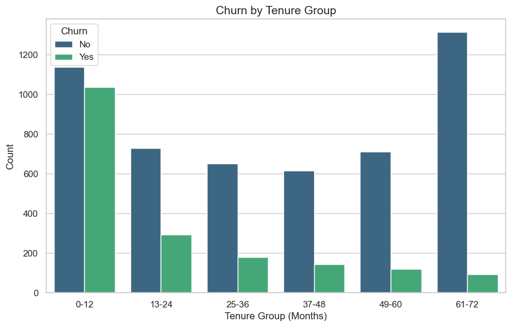

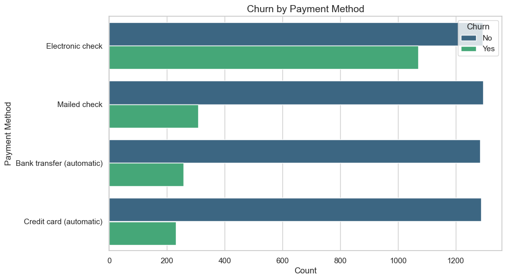

```python
import matplotlib.pyplot as plt
import seaborn as sns

# Set a style for the plots
sns.set(style="whitegrid")

# Step 1: Visualize the churn distribution
plt.figure(figsize=(6, 4))
sns.countplot(data=churn_data_cleaned, x='Churn', palette='viridis')
plt.title('Churn Distribution', fontsize=14)
plt.xlabel('Churn', fontsize=12)
plt.ylabel('Count', fontsize=12)
plt.show()

# Step 2: Analyze churn based on contract type
plt.figure(figsize=(8, 5))
sns.countplot(data=churn_data_cleaned, x='Contract', hue='Churn', palette='viridis')
plt.title('Churn by Contract Type', fontsize=14)
plt.xlabel('Contract Type', fontsize=12)
plt.ylabel('Count', fontsize=12)
plt.legend(title='Churn')
plt.show()

# Step 3: Analyze churn based on tenure (categorizing tenure into bins)
churn_data_cleaned['TenureGroup'] = pd.cut(churn_data_cleaned['tenure'],
                                           bins=[0, 12, 24, 36, 48, 60, 72],
                                           labels=['0-12', '13-24', '25-36', '37-48', '49-60', '61-72'])

plt.figure(figsize=(10, 6))
sns.countplot(data=churn_data_cleaned, x='TenureGroup', hue='Churn', palette='viridis')
plt.title('Churn by Tenure Group', fontsize=14)
plt.xlabel('Tenure Group (Months)', fontsize=12)
plt.ylabel('Count', fontsize=12)
plt.legend(title='Churn')
plt.show()

# Step 4: Analyze churn based on payment method
plt.figure(figsize=(10, 6))
sns.countplot(data=churn_data_cleaned, y='PaymentMethod', hue='Churn', palette='viridis')
plt.title('Churn by Payment Method', fontsize=14)
plt.xlabel('Count', fontsize=12)
plt.ylabel('Payment Method', fontsize=12)
plt.legend(title='Churn')
plt.show()
```

# DATA PREPROCESSING:-

This code performs preprocessing on a dataset (`churn_data_cleaned`), including converting categorical variables to numerical values and normalizing numerical features. Here's a breakdown:

1. **One-Hot Encoding for Categorical Variables**:
   - `categorical_columns` selects columns with object data types (i.e., categorical variables), excluding the 'customerID' column.
   - `pd.get_dummies()` converts the categorical columns to binary (0/1) columns, using one-hot encoding, while `drop_first=True` avoids multicollinearity by dropping the first category in each column.
2. **Normalization of Numerical Features**:
   - `MinMaxScaler()` scales the specified numerical columns (`tenure`, `MonthlyCharges`, `TotalCharges`) to a range between 0 and 1, ensuring features are on the same scale, which is often required for machine learning algorithms.
3. **Summary of the Preprocessed Data**:
   - `churn_data_encoded.info()` prints a summary of the dataset, showing the data types and non-null counts.
4. **Preview of the Preprocessed Data**:
   - `churn_data_encoded.head()` shows the first five rows of the transformed dataset to give a preview of the changes.

This code transforms categorical data and scales numerical features to prepare the dataset for further analysis or modeling.

```python
import pandas as pd
from sklearn.preprocessing import MinMaxScaler

# Step 1: Convert categorical variables to numerical (One-Hot Encoding)
# Exclude 'customerID' since it's a unique identifier for each customer
categorical_columns = churn_data_cleaned.select_dtypes(include=['object']).columns.drop('customerID')
# Drop the 'customerID' column from the DataFrame
churn_data_cleaned = churn_data_cleaned.drop(columns=['customerID'])

# Verify the column is removed
print(churn_data_cleaned.head())

# Perform one-hot encoding
churn_data_encoded = pd.get_dummies(churn_data_cleaned, columns=categorical_columns, drop_first=True)

# Step 2: Normalize the numerical columns
# Initialize the Min-Max Scaler
scaler = MinMaxScaler()

# Numerical columns to normalize
numerical_columns = ['tenure', 'MonthlyCharges', 'TotalCharges']

# Normalize the numerical columns
churn_data_encoded[numerical_columns] = scaler.fit_transform(churn_data_encoded[numerical_columns])

# Step 3: Summary of the preprocessed dataset
print("Preprocessed Dataset Summary:")
print(churn_data_encoded.info())

# Step 4: Preview the preprocessed data
print("\nPreview of Preprocessed Dataset:")
print(churn_data_encoded.head())
```

```
   tenure PhoneService        Contract PaperlessBilling  \
0       1           No  Month-to-month              Yes
1      34          Yes        One year               No
2       2          Yes  Month-to-month              Yes
3      45           No        One year               No
4       2          Yes  Month-to-month              Yes

               PaymentMethod  MonthlyCharges  TotalCharges Churn
0           Electronic check           29.85         29.85    No
1               Mailed check           56.95       1889.50    No
2               Mailed check           53.85        108.15   Yes
3  Bank transfer (automatic)           42.30       1840.75    No
4           Electronic check           70.70        151.65   Yes
Preprocessed Dataset Summary:
<class 'pandas.core.frame.DataFrame'>
Index: 7032 entries, 0 to 7042
Data columns (total 11 columns):
 #   Column                                 Non-Null Count  Dtype
---  ------                                 --------------  -----
 0   tenure                                 7032 non-null   float64
 1   MonthlyCharges                         7032 non-null   float64
 2   TotalCharges                           7032 non-null   float64
 3   PhoneService_Yes                       7032 non-null   bool
 4   Contract_One year                      7032 non-null   bool
 5   Contract_Two year                      7032 non-null   bool
 6   PaperlessBilling_Yes                   7032 non-null   bool
 7   PaymentMethod_Credit card (automatic)  7032 non-null   bool
 8   PaymentMethod_Electronic check         7032 non-null   bool
 9   PaymentMethod_Mailed check             7032 non-null   bool
 10  Churn_Yes                              7032 non-null   bool
dtypes: bool(8), float64(3)
memory usage: 274.7 KB
None

Preview of Preprocessed Dataset:
     tenure  MonthlyCharges  TotalCharges  PhoneService_Yes  \
0  0.000000        0.115423      0.001275             False
1  0.464789        0.385075      0.215867              True
2  0.014085        0.354229      0.010310              True
3  0.619718        0.239303      0.210241             False
4  0.014085        0.521891      0.015330              True

   Contract_One year  Contract_Two year  PaperlessBilling_Yes  \
0              False              False                  True
1               True              False                 False
2              False              False                  True
3               True              False                 False
4              False              False                  True

   PaymentMethod_Credit card (automatic)  PaymentMethod_Electronic check  \
0                                  False                            True
1                                  False                           False
2                                  False                           False
3                                  False                           False
4                                  False                            True

   PaymentMethod_Mailed check  Churn_Yes
0                       False      False
1                        True      False
2                        True       True
3                       False      False
4                       False       True
```

# 1. Visualizing the Data:

Histograms: To visualize the distribution of numerical features (like tenure, MonthlyCharges, and TotalCharges). Box Plots: Useful to understand the spread of data and detect outliers in numerical features. Scatter Plots: To explore relationships between pairs of numerical features (e.g., tenure vs. MonthlyCharges).

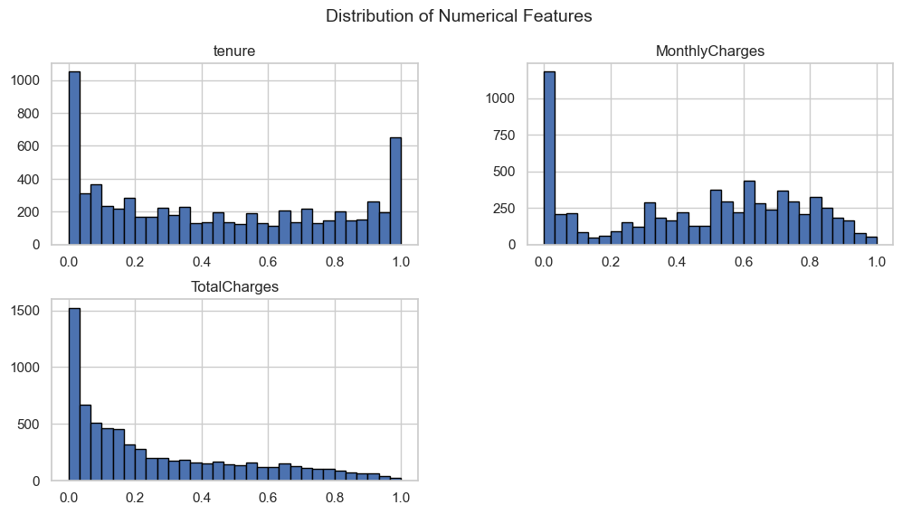

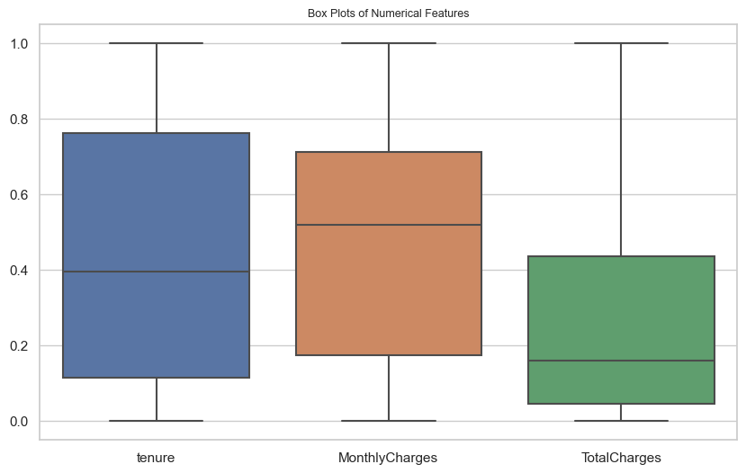

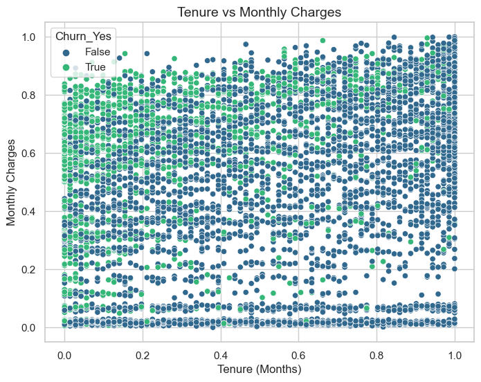

```python
import matplotlib.pyplot as plt
import seaborn as sns

# Set the plot style
sns.set(style="whitegrid")

# Step 1: Visualize the distribution of numerical columns
plt.figure(figsize=(12, 6))
churn_data_encoded[['tenure', 'MonthlyCharges', 'TotalCharges']].hist(bins=30, edgecolor='black', figsize=(12, 6))
plt.suptitle('Distribution of Numerical Features', fontsize=14)
plt.show()

# Step 2: Box plots to identify outliers
plt.figure(figsize=(10, 6))
sns.boxplot(data=churn_data_encoded[['tenure', 'MonthlyCharges', 'TotalCharges']])
plt.title('Box Plots of Numerical Features', fontsize=9)
plt.show()

# Step 3: Scatter plot to visualize relationships between tenure and MonthlyCharges
plt.figure(figsize=(8, 6))
sns.scatterplot(data=churn_data_encoded, x='tenure', y='MonthlyCharges',hue='Churn_Yes',palette='viridis')
plt.title('Tenure vs Monthly Charges', fontsize=14)
plt.xlabel('Tenure (Months)', fontsize=12)
plt.ylabel('Monthly Charges', fontsize=12)
plt.show()
```

```python
# Check the columns in the encoded DataFrame
print(churn_data_encoded.columns)
```

[output not shown]

# 2. Correlation Analysis:

Correlation Heatmap: Helps to identify relationships between numerical features (e.g., if tenure and TotalCharges are highly correlated).

Scatter Plots: For a more visual understanding of how variables relate to one another.

[figure not shown]

```python
# Step 1: Calculate correlations between numerical features
corr_matrix = churn_data_encoded[['tenure', 'MonthlyCharges', 'TotalCharges']].corr()

# Step 2: Plot a heatmap of correlations
plt.figure(figsize=(4, 3))
sns.heatmap(corr_matrix, annot=True, cmap='coolwarm', fmt='.2f', linewidths=0.5)
plt.title('Correlation Heatmap of Numerical Features', fontsize=10)
plt.show()
```

# 3. Analyze Feature Importance:

Statistical Tests: Conduct tests like Chi-square for categorical variables or ANOVA for numerical variables to check if they significantly affect the target variable (Churn). Feature Importance via a Model: Use a tree-based model like Random Forest to get an estimate of feature importance.

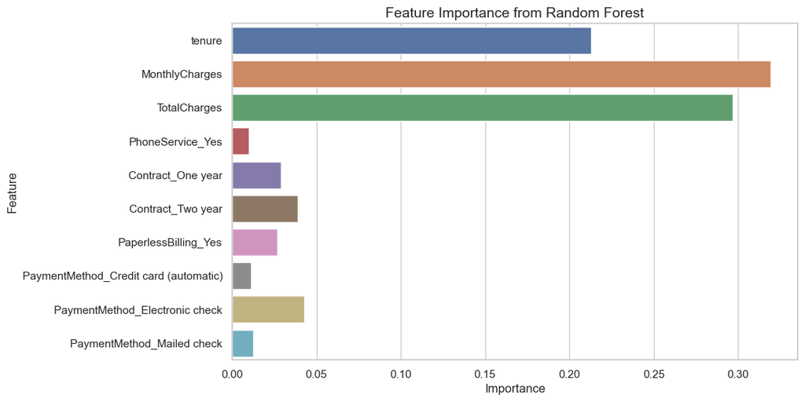

```python
from sklearn.ensemble import RandomForestClassifier

# Step 1: Prepare the data
X = churn_data_encoded.drop('Churn_Yes', axis=1)  # Features
y = churn_data_encoded['Churn_Yes']  # Target variable

# Step 2: Train a RandomForest model to get feature importances
rf_model = RandomForestClassifier(n_estimators=100, random_state=42)
rf_model.fit(X, y)

# Step 3: Plot the feature importances
plt.figure(figsize=(10, 6))
sns.barplot(x=rf_model.feature_importances_, y=X.columns)
plt.title('Feature Importance from Random Forest', fontsize=14)
plt.xlabel('Importance', fontsize=12)
plt.ylabel('Feature', fontsize=12)
plt.show()
```

# 3. Data Splitting

Divide the dataset into training, validation, and test sets (e.g., 70% training, 15% validation, 15% testing). Use stratified splitting to maintain the proportion of churners and non-churners in each set.

OUtPut Explanation: The output you provided describes the dimensions (shape) of the training, validation, and testing datasets after splitting. Here's what each part means:

### General Format:

- **(Rows, Columns)**:
  - Rows represent the number of samples (data points).
  - Columns represent the number of features (independent variables).

### Breakdown of Your Output:

1. **Training Set: (4922, 10) (4922, 1)**
   - **Features (X_train):** `(4922, 10)`
     - There are **4922 samples** in the training set.
     - Each sample has **10 features** (columns).
   - **Target (y_train):** `(4922, 1)`
     - There are **4922 target labels** (churn or not churn), with 1 column representing the target variable.
2. **Validation Set: (1055, 10) (1055, 1)**
   - **Features (X_val):** `(1055, 10)`
     - There are **1055 samples** in the validation set.
     - Each sample has **10 features** (columns).
   - **Target (y_val):** `(1055, 1)`
     - There are **1055 target labels**, with 1 column representing the target variable.
3. **Testing Set: (1055, 10) (1055, 1)**
   - **Features (X_test):** `(1055, 10)`
     - There are **1055 samples** in the testing set.
     - Each sample has **10 features** (columns).
   - **Target (y_test):** `(1055, 1)`
     - There are **1055 target labels**, with 1 column representing the target variable.

### Meaning:

- The data has been split into three subsets:
  - **Training Set (4922 samples):** Used to train the model.
  - **Validation Set (1055 samples):** Used to tune the model’s hyperparameters and prevent overfitting.
  - **Testing Set (1055 samples):** Used to evaluate the final model’s performance on unseen data.

### Why Splitting Is Done:

- **Training Set:** The model learns patterns and relationships from this data.
- **Validation Set:** Helps in fine-tuning and selecting the best model configuration without testing on unseen data.
- **Testing Set:** Provides an unbiased evaluation of the model's generalization ability.

The ratios in your data splitting suggest approximately 70% for training and 15% each for validation and testing, which is a common practice in machine learning.

```python
# Importing necessary libraries
import pandas as pd
from sklearn.model_selection import train_test_split

# Assuming 'data' is your DataFrame and 'target' is the column for churn prediction
# Example: data = pd.read_csv("churn_data.csv")

# Features (X) and target variable (y)
X = churn_data_encoded.drop(columns=['Churn_Yes'])  # Replace 'Churn' with the actual target column name
y = churn_data_encoded[['Churn_Yes']]

# Splitting the data into training, validation, and testing sets
# First split into train+validation and test
X_train_val, X_test, y_train_val, y_test = train_test_split(
    X, y, test_size=0.15, stratify=y, random_state=42
)

# Next, split train+validation into training and validation sets
X_train, X_val, y_train, y_val = train_test_split(
    X_train_val, y_train_val, test_size=0.15 / 0.85, stratify=y_train_val, random_state=42
)

# Display the shapes of the splits
print("Training Set:", X_train.shape, y_train.shape)
print("Validation Set:", X_val.shape, y_val.shape)
print("Testing Set:", X_test.shape, y_test.shape)
```

```
Training Set: (4922, 10) (4922, 1)
Validation Set: (1055, 10) (1055, 1)
Testing Set: (1055, 10) (1055, 1)
```

# MODEL SELECTION

Baseline Models: Start with simple models like Logistic Regression for interpretability. Advanced Models: Experiment with more complex models such as: Decision Trees Random Forests Gradient Boosting (e.g., XGBoost, LightGBM, CatBoost) Support Vector Machines (SVM) Neural Networks

```python
# Import necessary libraries
import pandas as pd
from sklearn.model_selection import train_test_split
from sklearn.ensemble import RandomForestClassifier, GradientBoostingClassifier
from sklearn.linear_model import LogisticRegression
from sklearn.svm import SVC
from sklearn.metrics import accuracy_score, precision_score, recall_score, f1_score

# Assuming X_train, X_val, y_train, y_val are already defined
# Example for creating the splits (uncomment if needed):
# X_train, X_val, y_train, y_val = train_test_split(
#     X, y, test_size=0.15, stratify=y, random_state=42
# )

# Ensure y_train and y_val are 1D arrays to avoid warnings
y_train = y_train.values.ravel()  # Convert to 1D
y_val = y_val.values.ravel()      # Convert to 1D

# Define the models to evaluate
models = {
    "Logistic Regression": LogisticRegression(max_iter=1000, random_state=42),
    "Random Forest": RandomForestClassifier(random_state=42),
    "SVM (Support Vector Machine)": SVC(probability=True, random_state=42),
    "Gradient Boosting": GradientBoostingClassifier(random_state=42),
}

# Evaluate models
results = {}

for model_name, model in models.items():
    # Train the model
    model.fit(X_train, y_train)

    # Predict on validation set
    y_val_pred = model.predict(X_val)

    # Calculate metrics
    accuracy = accuracy_score(y_val, y_val_pred)
    precision = precision_score(y_val, y_val_pred, pos_label=1)
    recall = recall_score(y_val, y_val_pred, pos_label=1)
    f1 = f1_score(y_val, y_val_pred, pos_label=1)

    # Store results
    results[model_name] = {
        "Accuracy": accuracy,
        "Precision": precision,
        "Recall": recall,
        "F1-Score": f1,
    }

# Print results
print("Model Selection Results:")
for model_name, metrics in results.items():
    print(f"\n{model_name}:")
    for metric, value in metrics.items():
        print(f"  {metric}: {value:.4f}")

# Select the best model based on F1-Score
best_model = max(results, key=lambda x: results[x]["F1-Score"])
print(f"\nBest Model: {best_model}")
```

```
Model Selection Results:

Logistic Regression:
  Accuracy: 0.7972
  Precision: 0.6650
  Recall: 0.4750
  F1-Score: 0.5542

Random Forest:
  Accuracy: 0.7754
  Precision: 0.6049
  Recall: 0.4429
  F1-Score: 0.5113

SVM (Support Vector Machine):
  Accuracy: 0.7953
  Precision: 0.6975
  Recall: 0.4036
  F1-Score: 0.5113

Gradient Boosting:
  Accuracy: 0.7886
  Precision: 0.6557
  Recall: 0.4286
  F1-Score: 0.5184

Best Model: Logistic Regression
```

```
Model Evaluation on Test Set:
Accuracy: 0.7763
Precision: 0.5948
Recall: 0.4929
F1-Score: 0.5391
ROC-AUC: 0.8285
```

[figure not shown]

```
Classification Report:
              precision    recall  f1-score   support

   Not Churn       0.83      0.88      0.85       775
       Churn       0.59      0.49      0.54       280

    accuracy                           0.78      1055
   macro avg       0.71      0.69      0.70      1055
weighted avg       0.77      0.78      0.77      1055
```

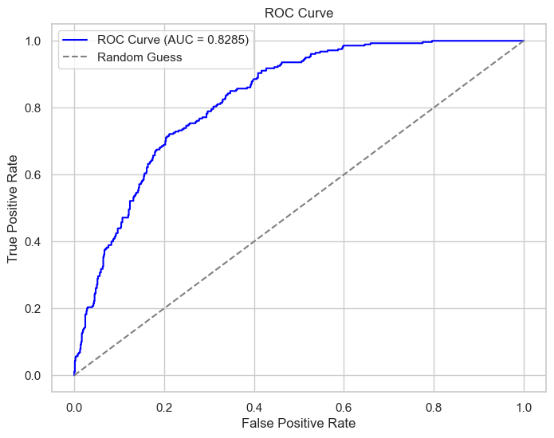

```python
#MOdel Eval
# Import necessary libraries
from sklearn.metrics import (
    accuracy_score,
    precision_score,
    recall_score,
    f1_score,
    confusion_matrix,
    classification_report,
    roc_auc_score,
    roc_curve
)
import matplotlib.pyplot as plt
import seaborn as sns

# Assuming the best model is trained (replace 'LogisticRegression' with your best model if needed)
best_model = LogisticRegression(max_iter=1000, random_state=42)
best_model.fit(X_train, y_train)  # Train the best model on training data

# Predict on test set
y_test_pred = best_model.predict(X_test)
y_test_prob = best_model.predict_proba(X_test)[:, 1]  # For ROC-AUC

# Calculate metrics
accuracy = accuracy_score(y_test, y_test_pred)
precision = precision_score(y_test, y_test_pred, pos_label=1)
recall = recall_score(y_test, y_test_pred, pos_label=1)
f1 = f1_score(y_test, y_test_pred, pos_label=1)
roc_auc = roc_auc_score(y_test, y_test_prob)

# Print metrics
print("Model Evaluation on Test Set:")
print(f"Accuracy: {accuracy:.4f}")
print(f"Precision: {precision:.4f}")
print(f"Recall: {recall:.4f}")
print(f"F1-Score: {f1:.4f}")
print(f"ROC-AUC: {roc_auc:.4f}")

# Confusion matrix
conf_matrix = confusion_matrix(y_test, y_test_pred)
plt.figure(figsize=(8, 6))
sns.heatmap(conf_matrix, annot=True, fmt='d', cmap='Blues', xticklabels=['Not Churn', 'Churn'], yticklabels=['Not Churn', 'Churn'])
plt.title("Confusion Matrix")
plt.xlabel("Predicted")
plt.ylabel("Actual")
plt.show()

# Classification report
print("\nClassification Report:")
print(classification_report(y_test, y_test_pred, target_names=['Not Churn', 'Churn']))

# Plot ROC Curve
fpr, tpr, thresholds = roc_curve(y_test, y_test_prob)
plt.figure(figsize=(8, 6))
plt.plot(fpr, tpr, color='blue', label=f'ROC Curve (AUC = {roc_auc:.4f})')
plt.plot([0, 1], [0, 1], color='gray', linestyle='--', label="Random Guess")
plt.xlabel("False Positive Rate")
plt.ylabel("True Positive Rate")
plt.title("ROC Curve")
plt.legend()
plt.show()
```

# hypermeter tuning

Understanding the Components fit()

Purpose: Learns the parameters or characteristics of the data. Example: In scaling, it calculates the mean and standard deviation of the data. transform()

Purpose: Applies the learned parameters to transform the data. Example: In scaling, it uses the calculated mean and standard deviation to scale the data. fit_transform()

Combines the above two steps into one method. Used when you want to both learn from the data and transform it in a single step.

What is Hyperparameter Tuning? Hyperparameter tuning is the process of finding the optimal combination of hyperparameters for a machine learning model to improve its performance. Hyperparameters are the settings or configurations of a model that must be set before training begins (e.g., the learning rate, number of trees in a Random Forest, or kernel in SVM).

Unlike model parameters, which are learned during training (e.g., weights in a neural network), hyperparameters are set manually or tuned using automated techniques.

```python
#1.random Search:-
from sklearn.model_selection import RandomizedSearchCV
from scipy.stats import randint

# Define parameter distributions
param_dist = {
    'n_estimators': randint(100, 500),        # Random integers between 100 and 500
    'max_depth': [None, 10, 20, 30],          # Predefined depths
    'min_samples_split': randint(2, 20),      # Random integers between 2 and 20
    'min_samples_leaf': randint(1, 10),       # Random integers between 1 and 10
}

# Initialize the model
rf_model = RandomForestClassifier(random_state=42)

# Perform Randomized Search
random_search = RandomizedSearchCV(estimator=rf_model, param_distributions=param_dist,
                                   scoring='f1', n_iter=50, cv=5, verbose=2, random_state=42, n_jobs=-1)
random_search.fit(X_train, y_train)

# Best parameters and score
print("Best Parameters from Random Search:", random_search.best_params_)
print("Best F1-Score from Random Search:", random_search.best_score_)

# Evaluate on validation set
best_rf_model = random_search.best_estimator_
y_val_pred = best_rf_model.predict(X_val)
f1 = f1_score(y_val, y_val_pred, pos_label=1)
print("F1-Score on Validation Set with Best Model:", f1)
```

```
Fitting 5 folds for each of 50 candidates, totalling 250 fits
Best Parameters from Random Search: {'max_depth': 20, 'min_samples_leaf': 6, 'min_samples_split': 3, 'n_estimators': 443}
Best F1-Score from Random Search: 0.5637640592877619
F1-Score on Validation Set with Best Model: 0.5247311827956989
```

```python
#2.Grid Search:-
from sklearn.model_selection import GridSearchCV

# Example: Hyperparameter tuning for RandomForestClassifier
param_grid = {
    'n_estimators': [100, 200, 300],   # Number of trees in the forest
    'max_depth': [None, 10, 20, 30],  # Maximum depth of the tree
    'min_samples_split': [2, 5, 10],  # Minimum samples required to split a node
    'min_samples_leaf': [1, 2, 4],    # Minimum samples required at each leaf node
}

# Initialize the model
rf_model = RandomForestClassifier(random_state=42)

# Perform Grid Search
grid_search = GridSearchCV(estimator=rf_model, param_grid=param_grid,
                           scoring='f1', cv=5, verbose=2, n_jobs=-1)
grid_search.fit(X_train, y_train)

# Best parameters and score
print("Best Parameters from Grid Search:", grid_search.best_params_)
print("Best F1-Score from Grid Search:", grid_search.best_score_)

# Evaluate on validation set
best_rf_model = grid_search.best_estimator_
y_val_pred = best_rf_model.predict(X_val)
f1 = f1_score(y_val, y_val_pred, pos_label=1)
print("F1-Score on Validation Set with Best Model:", f1)
```

```
Fitting 5 folds for each of 108 candidates, totalling 540 fits
Best Parameters from Grid Search: {'max_depth': 10, 'min_samples_leaf': 4, 'min_samples_split': 10, 'n_estimators': 100}
Best F1-Score from Grid Search: 0.5611055572959263
F1-Score on Validation Set with Best Model: 0.5347826086956521
```

# Adress class impbalance

1. **Class imbalance** occurs when one class significantly outnumbers the other, leading to biased predictions favoring the majority class.
2. **Oversampling** (e.g., SMOTE) creates synthetic samples for the minority class, while **undersampling** reduces majority class samples.
3. **Class weight adjustment** assigns higher penalties for misclassifying the minority class, supported in models like Random Forest and Logistic Regression.
4. **Cost-sensitive learning** modifies algorithms to prioritize the minority class during training.
5. **Ensemble techniques** like BalancedRandomForestClassifier handle imbalanced datasets effectively.
6. **Evaluation metrics** such as Precision, Recall, F1-Score, and ROC-AUC are better suited for imbalanced data than accuracy.
7. Combining these methods ensures robust performance and fair predictions for the minority class.

CODE explanation:- This code snippet demonstrates how to use **SMOTE (Synthetic Minority Oversampling Technique)** to balance an imbalanced dataset by oversampling the minority class in the training data. Here's what each part does:

### **Code Breakdown:**

1. **Import SMOTE**:  
   `from imblearn.over_sampling import SMOTE` imports the SMOTE module from the `imblearn` library.
2. **Initialize SMOTE**:  
   `smote = SMOTE(random_state=42)` creates an instance of SMOTE with a fixed random seed for reproducibility.
3. **Apply SMOTE to Training Data**:  
   `X_train_balanced, y_train_balanced = smote.fit_resample(X_train, y_train)`:
   - **`fit_resample`** learns the data distribution from `X_train` and `y_train` and generates synthetic samples for the minority class.
   - The balanced data is stored in `X_train_balanced` and `y_train_balanced`.
4. **Check Class Distribution**:  
   `print(pd.Series(y_train_balanced).value_counts())` displays the count of each class in the new, balanced training set.

### **Expected Output Example:**

Before SMOTE:

```
Class Distribution:
0    4000
1     500
```

After SMOTE:

```
Class Distribution After SMOTE:
0    4000
1    4000
```

### **Key Benefits:**

- SMOTE avoids simply duplicating minority class samples by generating synthetic data.
- Helps models better learn patterns for the minority class, improving metrics like Recall and F1-Score.

Let me know if you'd like further guidance! 😊

```python
from imblearn.over_sampling import SMOTE

# Apply SMOTE to training data
smote = SMOTE(random_state=42)
X_train_balanced, y_train_balanced = smote.fit_resample(X_train, y_train)

# Check the new class distribution
print("Class Distribution After SMOTE:")
print(pd.Series(y_train_balanced).value_counts())
```

```
Class Distribution After SMOTE:
False    3613
True     3613
Name: count, dtype: int64
```

# **Deployment Preparation and Post-Deployment Monitoring**

#### **1. Deployment Preparation**

Deployment involves making your model available for real-world use, often as a web service or API. It requires a few key steps to ensure that your model performs well in production.

##### **Key Steps for Deployment Preparation:**

1. **Model Exporting**:
   - Save the trained model to a file so it can be loaded in the deployment environment.
   - Common formats:
     - **Pickle** (`joblib` or `pickle` in Python)
     - **ONNX** (Open Neural Network Exchange)
   - Example:

     ```
     import joblib
     joblib.dump(model, 'churn_model.pkl')
     ```

2. **Creating a Service/Endpoint**:
   - Use frameworks like **Flask**, **FastAPI**, or **Django** to wrap your model into a REST API.
   - Example (Flask):

     ```
     from flask import Flask, request, jsonify
     import joblib

     app = Flask(__name__)
     model = joblib.load('churn_model.pkl')

     @app.route('/predict', methods=['POST'])
     def predict():
         data = request.get_json()
         prediction = model.predict([data['features']])
         return jsonify(prediction.tolist())

     if __name__ == '__main__':
         app.run(debug=True)
     ```

3. **Containerization**:
   - Use **Docker** to containerize the model and the application to ensure consistency across different environments.
   - **Dockerfile**:

     ```
     FROM python:3.8-slim
     COPY . /app
     WORKDIR /app
     RUN pip install -r requirements.txt
     CMD ["python", "app.py"]
     ```

4. **Scalability & Load Balancing**:
   - Use **Kubernetes** or cloud services (e.g., **AWS Lambda**, **Azure Functions**) to scale your application.
   - Ensure that your deployment architecture can handle high traffic if necessary.
5. **Environment Considerations**:
   - Ensure the environment for deployment has the necessary software dependencies, such as Python libraries, server configurations, etc.
   - Set up version control for the code and model (e.g., using **Git**, **Model Versioning Tools**).

#### **2. Post-Deployment Monitoring**

After deployment, continuous monitoring is essential to track the model’s performance and ensure that it continues to provide value.

##### **Key Areas for Post-Deployment Monitoring:**

1. **Model Performance Monitoring**:
   - **Accuracy**: Regularly track model accuracy, precision, recall, F1-score, etc., to ensure it meets performance expectations.
   - **Data Drift**: Monitor for any significant changes in the data distribution (i.e., input features) over time.
     - **Tools**: **Evidently AI**, **WhyLabs** to track data and model performance over time.
     - **Action**: Retrain the model periodically or trigger automatic retraining if necessary.
2. **Model Monitoring Tools**:
   - Use specialized tools for tracking model health, latency, and throughput.
     - **MLflow**, **Kubeflow**, **TensorFlow Serving** for managing and serving models.
     - **Prometheus** and **Grafana** for system performance monitoring.
3. **Error Tracking and Logging**:
   - Log model predictions, input data, and errors.
   - Use logging tools (e.g., **Logstash**, **Sentry**) to capture anomalies and model failures.
4. **Feedback Loops**:
   - Incorporate user or system feedback on model predictions to identify any wrong predictions or issues in real-time.
   - Use feedback to fine-tune the model or trigger retraining.
5. **Alerts and Notifications**:
   - Set up alerts for abnormal behavior such as:
     - Model performance drops below a threshold.
     - Inference time is higher than expected.
     - High error rates.
   - Use **Slack**, **email notifications**, or **PagerDuty** for timely alerts.
6. **Retraining and Model Updates**:
   - Plan a retraining strategy based on performance monitoring, especially if the model is showing signs of degradation (concept drift).
   - **Automated retraining** can be set up through tools like **Kubeflow Pipelines**, **AWS SageMaker**, etc.
7. **A/B Testing**:
   - Use A/B testing to compare different model versions and observe which performs better in the production environment.
   - Gradually roll out new versions and monitor their impact.

```python
import joblib
joblib.dump(model, 'churn_model.pkl')
#Creating a Service/Endpoint:
from flask import Flask, request, jsonify
import joblib

app = Flask(__name__)
model = joblib.load('churn_model.pkl')

@app.route('/predict', methods=['POST'])
def predict():
    data = request.get_json()
    prediction = model.predict([data['features']])
    return jsonify(prediction.tolist())

if __name__ == '__main__':
    app.run(debug=True)
```

```
 * Serving Flask app '__main__'
 * Debug mode: on
```

```
WARNING: This is a development server. Do not use it in a production deployment. Use a production WSGI server instead.
 * Running on http://127.0.0.1:5000
Press CTRL+C to quit
 * Restarting with watchdog (windowsapi)
```

```
An exception has occurred, use %tb to see the full traceback.

SystemExit: 1
```